# تمرین کامپیوتری پنجم - Neural Networks and Deep Learning

# قسمت دوم(TensorFlow and Keras)

# نیما مدیرکیاسرایی 810198471

## هدف پروژه

در این بخش به کمک رابط Keras یک شبکه FeedForward ایجاد می کنیم که حداقل شما 2 لایه مخفی است. همچنین مجموعه داده CIFAR-10 دیتاست مورد استفاده ما در این پروژه است که شامل 10 کلاس مختلف هواپیما، ماشین، پرنده، گربه، آهو، سگ، قورباغه، اسب، کشتی و کامیون می باشد.

```python
import tensorflow as tf
import numpy as np
import matplotlib.pyplot as plt
import seaborn as sns
from tensorflow.keras.utils import plot_model
from tensorflow.keras.utils import to_categorical
from tensorflow.keras import optimizers
from tensorflow.keras.layers import Dense
from tensorflow.keras import layers
from tensorflow.keras import models
from sklearn.metrics import confusion_matrix, classification_report
```

# قسمت اول) آماده کردن داده و طراحی شبکه عصبی

```python
cifar10 = tf.keras.datasets.cifar10
(train_img, train_label), (test_img, test_label) = cifar10.load_data()
```

```
Downloading data from https://www.cs.toronto.edu/~kriz/cifar-10-python.tar.gz
```

[output not shown]

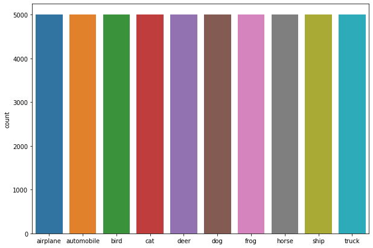

```python
classes = ['airplane', 'automobile', 'bird', 'cat', 'deer', 'dog', 'frog', 'horse', 'ship', 'truck']

plt.figure(figsize=(10,7))
p = sns.countplot(train_label.flatten())
p.set(xticklabels=classes)
```

تصاویر را به صورت یک بردار سطری reshape می کنیم :

```python
train_img = train_img.reshape(train_img.shape[0], train_img.shape[1]*train_img.shape[2]*train_img.shape[3])
test_img = test_img.reshape(test_img.shape[0], test_img.shape[1]*test_img.shape[2]*test_img.shape[3])
test_img = test_img.astype('float64')
train_img = train_img.astype('float64')
```

انجام دادن عملیات Normalization بر روی داده ها:

```python
train_img = train_img/255.0
test_img = test_img/255.0
```

برچسب های train و test را به حالت OneHot تبدیل می کنیم:

```python
train_label = to_categorical(train_label, 10)
test_label = to_categorical(test_label, 10)
```

## طراحی شبکه عصبی Sequential

Avtivation Function = RELU & Learning rate = 0.01

```python
network = models.Sequential()
network.add(layers.Input(3072))
network.add(layers.Flatten())
network.add(layers.Dense(4096, activation = 'relu'))
network.add(layers.Dense(2048, activation= 'relu'))
network.add(layers.Dense(1024, activation= 'relu'))
network.add(layers.Dense(512, activation= 'relu'))
network.add(layers.Dense(256, activation= 'relu'))
network.add(layers.Dense(128, activation= 'relu'))
network.add(layers.Dense(10, activation = 'softmax'))
network.compile(loss = 'categorical_crossentropy', optimizer = optimizers.SGD(learning_rate = 0.01), metrics= ['accuracy'])
```

```python
network.summary()
```

```
Model: "sequential_1"
_________________________________________________________________
 Layer (type)                Output Shape              Param #
=================================================================
 flatten_1 (Flatten)         (None, 3072)              0

 dense_4 (Dense)             (None, 4096)              12587008

 dense_5 (Dense)             (None, 2048)              8390656

 dense_6 (Dense)             (None, 1024)              2098176

 dense_7 (Dense)             (None, 512)               524800

 dense_8 (Dense)             (None, 256)               131328

 dense_9 (Dense)             (None, 128)               32896

 dense_10 (Dense)            (None, 10)                1290

=================================================================
Total params: 23,766,154
Trainable params: 23,766,154
Non-trainable params: 0
_________________________________________________________________
```

همانطور که در بالا می بینیم تعداد پارامترهای هر لایه به جز لایه ورودی عبارت است از تعداد نورون های هر لایه به اضافه حاصل ضرب تعداد نورون های همان لایه و تعداد نورون های لایه قبلی.( در واقع به عبارت دیگر برابر است با تعداد نورون های هر لایه ضربدر تعداد نورون های لایه قبل بعلاوه 1. دلیل آن هم این است که هر نورون در لایه یک مقدار بایاس و همچنین به ازای ورودی از هر نورون لایه قبل نیز یک وزن دارد. همچنین تمام پارامترها در شبکه عصبی ما نیز قابل آموزش هستند.

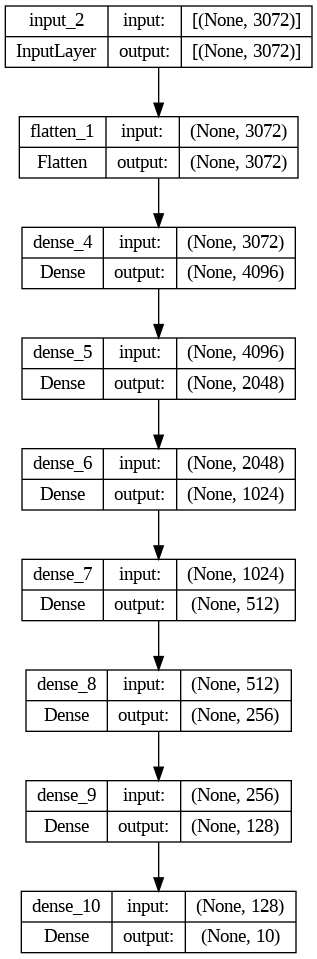

```python
plot_model(network, show_shapes=True, expand_nested=True)
```

```python
trained_network = network.fit(train_img, train_label, batch_size = 32, epochs = 10, validation_split = 0.1, verbose = 1)
```

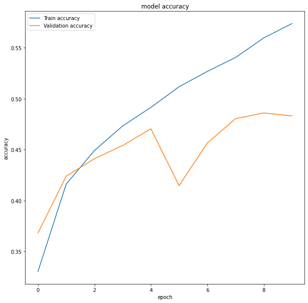

```python
loss_plt = plt.figure(figsize = (10, 10))
plt.plot(trained_network.history['accuracy'])
plt.plot(trained_network.history["val_accuracy"])
plt.title('model accuracy')
plt.ylabel('accuracy')
plt.xlabel('epoch')
plt.legend(["Train accuracy", "Validation accuracy"])
plt.show()
```

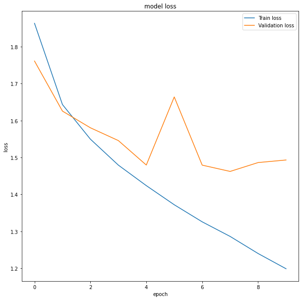

```python
loss_plt = plt.figure(figsize = (10, 10))
plt.plot(trained_network.history['loss'])
plt.plot(trained_network.history["val_loss"])
plt.title('model loss')
plt.ylabel('loss')
plt.xlabel('epoch')
plt.legend(["Train loss", "Validation loss"])
plt.show()
```

```python
test_loss, test_acc = network.evaluate(test_img, test_label, verbose = 0)
print("loss in test data is: ", test_loss)
print("accuracy in test data is : ", test_acc)
```

```
loss in test data is:  1.493735432624817
accuracy in test data is :  0.48100000619888306
```

```python
labels = ['1', '2', '3', '4', '5', '6', '7', '8', '9', '10']
real_label = np.argmax(test_label, axis = 1)
predicted_label = np.argmax(network.predict(test_img), axis = 1)

#confusionmatrix, and also f1, precision calcuation
print('Test : ')
print(classification_report(real_label, predicted_label, digits=10))

real_label = np.argmax(train_label, axis = 1)
predicted_label = np.argmax(network.predict(train_img), axis = 1)

#confusionmatrix, and also f1, precision calcuation
print('Train : ')
print(classification_report(real_label, predicted_label, digits=10))
```

```
Test :
              precision    recall  f1-score   support

           0  0.6234567901 0.5050000000 0.5580110497      1000
           1  0.6829004329 0.6310000000 0.6559251559      1000
           2  0.3398058252 0.4550000000 0.3890551518      1000
           3  0.4000000000 0.1500000000 0.2181818182      1000
           4  0.4662045061 0.2690000000 0.3411540900      1000
           5  0.5410764873 0.1910000000 0.2823355506      1000
           6  0.3100587625 0.8970000000 0.4608271256      1000
           7  0.7256198347 0.4390000000 0.5470404984      1000
           8  0.5932062966 0.7160000000 0.6488445854      1000
           9  0.6074154853 0.5570000000 0.5811163276      1000

    accuracy                      0.4810000000     10000
   macro avg  0.5289744421 0.4810000000 0.4682491353     10000
weighted avg  0.5289744421 0.4810000000 0.4682491353     10000

Train :
              precision    recall  f1-score   support

           0  0.6793145655 0.5550000000 0.6108970831      5000
           1  0.7543429389 0.7382000000 0.7461841706      5000
           2  0.3886866849 0.5126000000 0.4421252372      5000
           3  0.5528455285 0.2040000000 0.2980277575      5000
           4  0.5804002761 0.3364000000 0.4259306153      5000
           5  0.6749295775 0.2396000000 0.3536531365      5000
           6  0.3274197010 0.9154000000 0.4823225670      5000
           7  0.8157037037 0.5506000000 0.6574328358      5000
           8  0.6496699670 0.7874000000 0.7119349005      5000
           9  0.7315391459 0.6578000000 0.6927127211      5000

    accuracy                      0.5497000000     50000
   macro avg  0.6154852089 0.5497000000 0.5421221025     50000
weighted avg  0.6154852089 0.5497000000 0.5421221025     50000
```

Avtivation Function = RELU & Learning rate = 0.001

```python
network = models.Sequential()
network.add(layers.Input(3072))
network.add(layers.Flatten())
network.add(layers.Dense(4096, activation = 'relu'))
network.add(layers.Dense(2048, activation= 'relu'))
network.add(layers.Dense(1024, activation= 'relu'))
network.add(layers.Dense(512, activation= 'relu'))
network.add(layers.Dense(256, activation= 'relu'))
network.add(layers.Dense(128, activation= 'relu'))
network.add(layers.Dense(10, activation = 'softmax'))
network.compile(loss = 'categorical_crossentropy', optimizer = optimizers.SGD(learning_rate = 0.001), metrics= ['accuracy'])
```

```python
trained_network = network.fit(train_img, train_label, batch_size = 32, epochs = 10, validation_split = 0.1, verbose = 1)
```

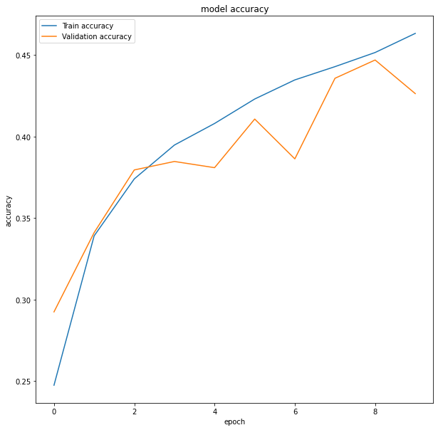

```python
loss_plt = plt.figure(figsize = (10, 10))
plt.plot(trained_network.history['accuracy'])
plt.plot(trained_network.history["val_accuracy"])
plt.title('model accuracy')
plt.ylabel('accuracy')
plt.xlabel('epoch')
plt.legend(["Train accuracy", "Validation accuracy"])
plt.show()
```

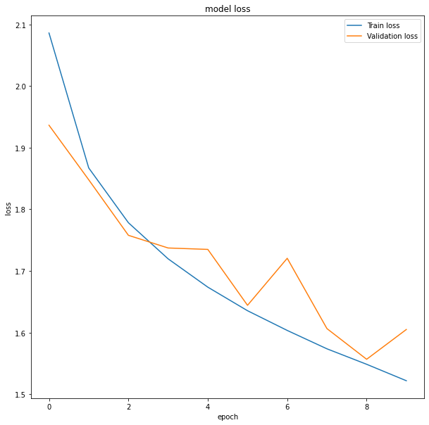

```python
loss_plt = plt.figure(figsize = (10, 10))
plt.plot(trained_network.history['loss'])
plt.plot(trained_network.history["val_loss"])
plt.title('model loss')
plt.ylabel('loss')
plt.xlabel('epoch')
plt.legend(["Train loss", "Validation loss"])
plt.show()
```

```python
test_loss, test_acc = network.evaluate(test_img, test_label, verbose = 0)
print("loss in test data is: ", test_loss)
print("accuracy in test data is : ", test_acc)
```

```
loss in test data is:  1.5968502759933472
accuracy in test data is :  0.4262000024318695
```

```python
labels = ['1', '2', '3', '4', '5', '6', '7', '8', '9', '10']
real_label = np.argmax(test_label, axis = 1)
predicted_label = np.argmax(network.predict(test_img), axis = 1)

#confusionmatrix, and also f1, precision calcuation
print('Test : ')
print(classification_report(real_label, predicted_label, digits=10))

real_label = np.argmax(train_label, axis = 1)
predicted_label = np.argmax(network.predict(train_img), axis = 1)

#confusionmatrix, and also f1, precision calcuation
print('Train : ')
print(classification_report(real_label, predicted_label, digits=10))
```

```
Test :
              precision    recall  f1-score   support

           0  0.4579158317 0.4570000000 0.4574574575      1000
           1  0.4075286416 0.7470000000 0.5273561595      1000
           2  0.3780487805 0.1860000000 0.2493297587      1000
           3  0.3064833006 0.3120000000 0.3092170466      1000
           4  0.5647058824 0.1440000000 0.2294820717      1000
           5  0.3181818182 0.3990000000 0.3540372671      1000
           6  0.5124593716 0.4730000000 0.4919396776      1000
           7  0.4858870968 0.4820000000 0.4839357430      1000
           8  0.4571428571 0.7360000000 0.5639846743      1000
           9  0.5216000000 0.3260000000 0.4012307692      1000

    accuracy                      0.4262000000     10000
   macro avg  0.4409953580 0.4262000000 0.4067970625     10000
weighted avg  0.4409953580 0.4262000000 0.4067970625     10000

Train :
              precision    recall  f1-score   support

           0  0.4594977724 0.4538000000 0.4566311129      5000
           1  0.4143178652 0.7732000000 0.5395296909      5000
           2  0.4282608696 0.1970000000 0.2698630137      5000
           3  0.3322938998 0.3410000000 0.3365906623      5000
           4  0.6393574297 0.1592000000 0.2549239392      5000
           5  0.3386662443 0.4276000000 0.3779722443      5000
           6  0.5026213814 0.4410000000 0.4697986577      5000
           7  0.5104666795 0.5316000000 0.5208190458      5000
           8  0.4746778926 0.7442000000 0.5796401589      5000
           9  0.5478996676 0.3626000000 0.4363942713      5000

    accuracy                      0.4431200000     50000
   macro avg  0.4648059702 0.4431200000 0.4242162797     50000
weighted avg  0.4648059702 0.4431200000 0.4242162797     50000
```

Avtivation Function = RELU & Learning rate = 0.1

```python
network = models.Sequential()
network.add(layers.Input(3072))
network.add(layers.Flatten())
network.add(layers.Dense(4096, activation = 'relu'))
network.add(layers.Dense(2048, activation= 'relu'))
network.add(layers.Dense(1024, activation= 'relu'))
network.add(layers.Dense(512, activation= 'relu'))
network.add(layers.Dense(256, activation= 'relu'))
network.add(layers.Dense(128, activation= 'relu'))
network.add(layers.Dense(10, activation = 'softmax'))
network.compile(loss = 'categorical_crossentropy', optimizer = optimizers.SGD(learning_rate = 0.1), metrics= ['accuracy'])
```

```python
trained_network = network.fit(train_img, train_label, batch_size = 32, epochs = 10, validation_split = 0.1, verbose = 1)
```

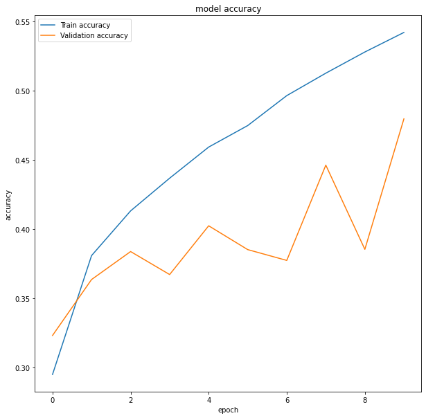

```python
loss_plt = plt.figure(figsize = (10, 10))
plt.plot(trained_network.history['accuracy'])
plt.plot(trained_network.history["val_accuracy"])
plt.title('model accuracy')
plt.ylabel('accuracy')
plt.xlabel('epoch')
plt.legend(["Train accuracy", "Validation accuracy"])
plt.show()
```

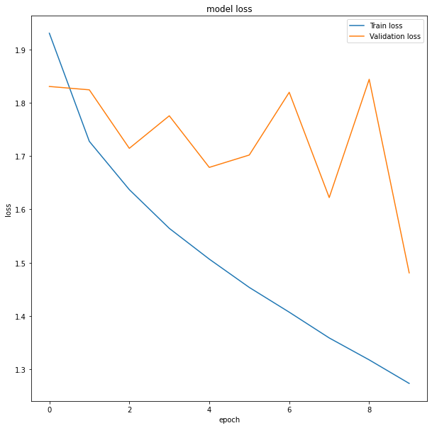

```python
loss_plt = plt.figure(figsize = (10, 10))
plt.plot(trained_network.history['loss'])
plt.plot(trained_network.history["val_loss"])
plt.title('model loss')
plt.ylabel('loss')
plt.xlabel('epoch')
plt.legend(["Train loss", "Validation loss"])
plt.show()
```

```python
test_loss, test_acc = network.evaluate(test_img, test_label, verbose = 0)
print("loss in test data is: ", test_loss)
print("accuracy in test data is : ", test_acc)
```

```
loss in test data is:  1.4912102222442627
accuracy in test data is :  0.46560001373291016
```

```python
labels = ['1', '2', '3', '4', '5', '6', '7', '8', '9', '10']
real_label = np.argmax(test_label, axis = 1)
predicted_label = np.argmax(network.predict(test_img), axis = 1)

#confusionmatrix, and also f1, precision calcuation
print('Test : ')
print(classification_report(real_label, predicted_label, digits=10))

real_label = np.argmax(train_label, axis = 1)
predicted_label = np.argmax(network.predict(train_img), axis = 1)

#confusionmatrix, and also f1, precision calcuation
print('Train : ')
print(classification_report(real_label, predicted_label, digits=10))
```

```
Test :
              precision    recall  f1-score   support

           0  0.6069930070 0.4340000000 0.5061224490      1000
           1  0.7893401015 0.3110000000 0.4461979914      1000
           2  0.3696303696 0.3700000000 0.3698150925      1000
           3  0.3717277487 0.1420000000 0.2054992764      1000
           4  0.3777777778 0.4930000000 0.4277657267      1000
           5  0.3212996390 0.6230000000 0.4239537258      1000
           6  0.5021231423 0.4730000000 0.4871266735      1000
           7  0.6482479784 0.4810000000 0.5522388060      1000
           8  0.5917782027 0.6190000000 0.6050830890      1000
           9  0.4628422425 0.7100000000 0.5603788477      1000

    accuracy                      0.4656000000     10000
   macro avg  0.5041760209 0.4656000000 0.4584181678     10000
weighted avg  0.5041760209 0.4656000000 0.4584181678     10000

Train :
              precision    recall  f1-score   support

           0  0.6644257703 0.4744000000 0.5535589265      5000
           1  0.8767667845 0.3970000000 0.5465308370      5000
           2  0.4320457797 0.4228000000 0.4273728899      5000
           3  0.4634517766 0.1826000000 0.2619799139      5000
           4  0.4342205323 0.5710000000 0.4933045356      5000
           5  0.3660393318 0.6924000000 0.4789044128      5000
           6  0.5851040996 0.5452000000 0.5644476654      5000
           7  0.7338927991 0.5422000000 0.6236484932      5000
           8  0.6583779648 0.6884000000 0.6730543606      5000
           9  0.5074782156 0.7804000000 0.6150208842      5000

    accuracy                      0.5296400000     50000
   macro avg  0.5721803054 0.5296400000 0.5237822919     50000
weighted avg  0.5721803054 0.5296400000 0.5237822919     50000
```

Avtivation Function = LeakyRelu & Learning rate = 0.01

```python
network = models.Sequential()
network.add(layers.Input(3072))
network.add(layers.Flatten())
network.add(layers.Dense(4096))
network.add(layers.LeakyReLU(alpha=0.05))
network.add(layers.Dense(2048))
network.add(layers.LeakyReLU(alpha=0.05))
network.add(layers.Dense(1024))
network.add(layers.LeakyReLU(alpha=0.05))
network.add(layers.Dense(512))
network.add(layers.LeakyReLU(alpha=0.05))
network.add(layers.Dense(256))
network.add(layers.LeakyReLU(alpha=0.05))
network.add(layers.Dense(128))
network.add(layers.LeakyReLU(alpha=0.05))
network.add(layers.Dense(10, activation = 'softmax'))
network.compile(loss = 'categorical_crossentropy', optimizer = optimizers.SGD(learning_rate = 0.01), metrics= ['accuracy'])
```

```python
network.summary()
```

```
Model: "sequential_2"
_________________________________________________________________
 Layer (type)                Output Shape              Param #
=================================================================
 flatten_2 (Flatten)         (None, 3072)              0

 dense_11 (Dense)            (None, 4096)              12587008

 leaky_re_lu (LeakyReLU)     (None, 4096)              0

 dense_12 (Dense)            (None, 2048)              8390656

 leaky_re_lu_1 (LeakyReLU)   (None, 2048)              0

 dense_13 (Dense)            (None, 1024)              2098176

 leaky_re_lu_2 (LeakyReLU)   (None, 1024)              0

 dense_14 (Dense)            (None, 512)               524800

 leaky_re_lu_3 (LeakyReLU)   (None, 512)               0

 dense_15 (Dense)            (None, 256)               131328

 leaky_re_lu_4 (LeakyReLU)   (None, 256)               0

 dense_16 (Dense)            (None, 128)               32896

 leaky_re_lu_5 (LeakyReLU)   (None, 128)               0

 dense_17 (Dense)            (None, 10)                1290

=================================================================
Total params: 23,766,154
Trainable params: 23,766,154
Non-trainable params: 0
_________________________________________________________________
```

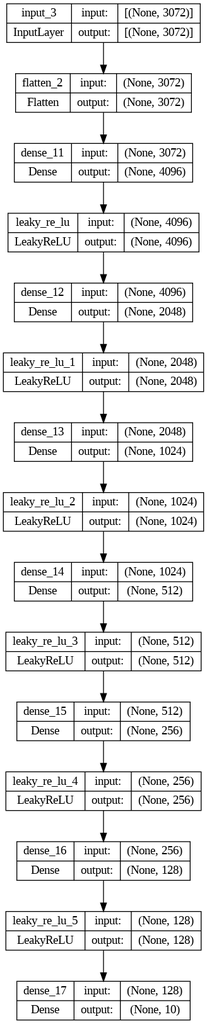

```python
plot_model(network, show_shapes=True, expand_nested=True)
```

```python
trained_network = network.fit(train_img, train_label, batch_size = 32, epochs = 10, validation_split = 0.1, verbose = 1)
```

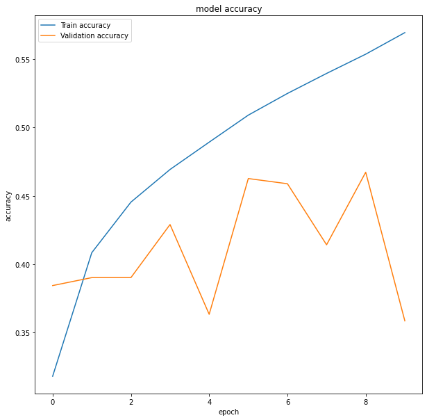

```python
loss_plt = plt.figure(figsize = (10, 10))
plt.plot(trained_network.history['accuracy'])
plt.plot(trained_network.history["val_accuracy"])
plt.title('model accuracy')
plt.ylabel('accuracy')
plt.xlabel('epoch')
plt.legend(["Train accuracy", "Validation accuracy"])
plt.show()
```

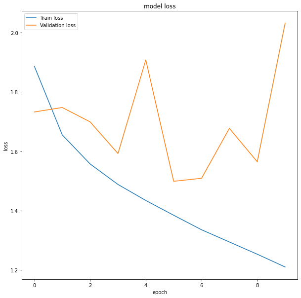

```python
loss_plt = plt.figure(figsize = (10, 10))
plt.plot(trained_network.history['loss'])
plt.plot(trained_network.history["val_loss"])
plt.title('model loss')
plt.ylabel('loss')
plt.xlabel('epoch')
plt.legend(["Train loss", "Validation loss"])
plt.show()
```

```python
test_loss, test_acc = network.evaluate(test_img, test_label, verbose = 0)
print("loss in test data is: ", test_loss)
print("accuracy in test data is : ", test_acc)
```

```
loss in test data is:  2.010629892349243
accuracy in test data is :  0.37459999322891235
```

```python
labels = ['1', '2', '3', '4', '5', '6', '7', '8', '9', '10']
real_label = np.argmax(test_label, axis = 1)
predicted_label = np.argmax(network.predict(test_img), axis = 1)

#confusionmatrix, and also f1, precision calcuation
print('Test : ')
print(classification_report(real_label, predicted_label, digits=10))

real_label = np.argmax(train_label, axis = 1)
predicted_label = np.argmax(network.predict(train_img), axis = 1)

#confusionmatrix, and also f1, precision calcuation
print('Train : ')
print(classification_report(real_label, predicted_label, digits=10))
```

```
Test :
              precision    recall  f1-score   support

           0  0.5418719212 0.4400000000 0.4856512141      1000
           1  0.7801047120 0.2980000000 0.4312590449      1000
           2  0.2847990681 0.4890000000 0.3599558336      1000
           3  0.2883008357 0.2070000000 0.2409778813      1000
           4  0.6820809249 0.1180000000 0.2011935209      1000
           5  0.3133666112 0.5650000000 0.4031394934      1000
           6  0.4821428571 0.5400000000 0.5094339623      1000
           7  0.2731607629 0.8020000000 0.4075203252      1000
           8  0.9181034483 0.2130000000 0.3457792208      1000
           9  0.6915887850 0.0740000000 0.1336946703      1000

    accuracy                      0.3746000000     10000
   macro avg  0.5255519926 0.3746000000 0.3518605167     10000
weighted avg  0.5255519926 0.3746000000 0.3518605167     10000

Train :
              precision    recall  f1-score   support

           0  0.5548064919 0.4444000000 0.4935036091      5000
           1  0.8338717120 0.3614000000 0.5042556160      5000
           2  0.3180127205 0.5300000000 0.3975099377      5000
           3  0.3678714859 0.2748000000 0.3145964511      5000
           4  0.6873747495 0.1372000000 0.2287429143      5000
           5  0.3612028302 0.6126000000 0.4544510386      5000
           6  0.5099730458 0.5676000000 0.5372456223      5000
           7  0.2825753022 0.8462000000 0.4236719571      5000
           8  0.9207365893 0.2300000000 0.3680588894      5000
           9  0.7676767677 0.0760000000 0.1383075523      5000

    accuracy                      0.4080200000     50000
   macro avg  0.5604101695 0.4080200000 0.3860343588     50000
weighted avg  0.5604101695 0.4080200000 0.3860343588     50000
```

Avtivation Function = Tanh & Learning rate = 0.01

```python
network = models.Sequential()
network.add(layers.Input(3072))
network.add(layers.Flatten())
network.add(layers.Dense(4096, activation = 'tanh'))
network.add(layers.Dense(2048, activation= 'tanh'))
network.add(layers.Dense(1024, activation= 'tanh'))
network.add(layers.Dense(512, activation= 'tanh'))
network.add(layers.Dense(256, activation= 'tanh'))
network.add(layers.Dense(128, activation= 'tanh'))
network.add(layers.Dense(10, activation = 'softmax'))
network.compile(loss = 'categorical_crossentropy', optimizer = optimizers.SGD(learning_rate = 0.01), metrics= ['accuracy'])
```

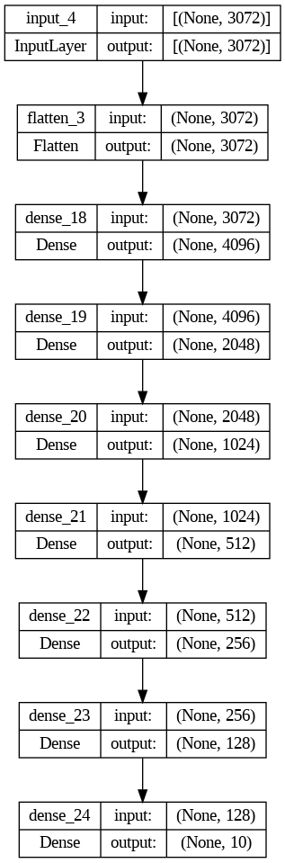

```python
plot_model(network, show_shapes=True, expand_nested=True)
```

```python
network.summary()
```

```
Model: "sequential_3"
_________________________________________________________________
 Layer (type)                Output Shape              Param #
=================================================================
 flatten_3 (Flatten)         (None, 3072)              0

 dense_18 (Dense)            (None, 4096)              12587008

 dense_19 (Dense)            (None, 2048)              8390656

 dense_20 (Dense)            (None, 1024)              2098176

 dense_21 (Dense)            (None, 512)               524800

 dense_22 (Dense)            (None, 256)               131328

 dense_23 (Dense)            (None, 128)               32896

 dense_24 (Dense)            (None, 10)                1290

=================================================================
Total params: 23,766,154
Trainable params: 23,766,154
Non-trainable params: 0
_________________________________________________________________
```

```python
trained_network = network.fit(train_img, train_label, batch_size = 32, epochs = 10, validation_split = 0.1, verbose = 1)
```

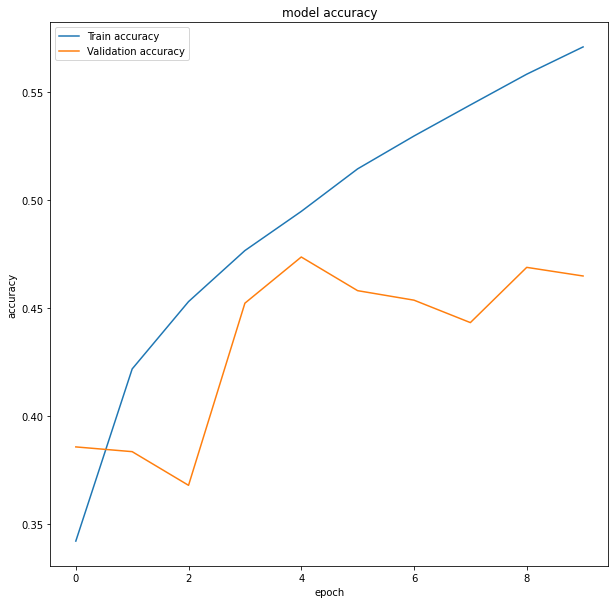

```python
loss_plt = plt.figure(figsize = (10, 10))
plt.plot(trained_network.history['accuracy'])
plt.plot(trained_network.history["val_accuracy"])
plt.title('model accuracy')
plt.ylabel('accuracy')
plt.xlabel('epoch')
plt.legend(["Train accuracy", "Validation accuracy"])
plt.show()
```

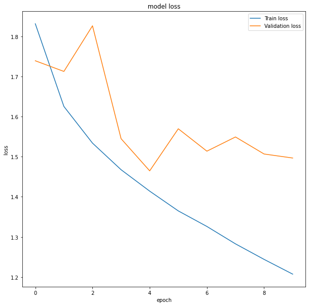

```python
loss_plt = plt.figure(figsize = (10, 10))
plt.plot(trained_network.history['loss'])
plt.plot(trained_network.history["val_loss"])
plt.title('model loss')
plt.ylabel('loss')
plt.xlabel('epoch')
plt.legend(["Train loss", "Validation loss"])
plt.show()
```

```python
test_loss, test_acc = network.evaluate(test_img, test_label, verbose = 0)
print("loss in test data is: ", test_loss)
print("accuracy in test data is : ", test_acc)
```

```
loss in test data is:  1.514940857887268
accuracy in test data is :  0.4627000093460083
```

```python
labels = ['1', '2', '3', '4', '5', '6', '7', '8', '9', '10']
real_label = np.argmax(test_label, axis = 1)
predicted_label = np.argmax(network.predict(test_img), axis = 1)

#confusionmatrix, and also f1, precision calcuation
print('Test : ')
print(classification_report(real_label, predicted_label, digits=10))

real_label = np.argmax(train_label, axis = 1)
predicted_label = np.argmax(network.predict(train_img), axis = 1)

#confusionmatrix, and also f1, precision calcuation
print('Train : ')
print(classification_report(real_label, predicted_label, digits=10))
```

```
Test :
              precision    recall  f1-score   support

           0  0.3711911357 0.6700000000 0.4777183601      1000
           1  0.6236897275 0.5950000000 0.6090071648      1000
           2  0.4106666667 0.3080000000 0.3520000000      1000
           3  0.4103585657 0.2060000000 0.2743009321      1000
           4  0.4784768212 0.2890000000 0.3603491272      1000
           5  0.3417721519 0.5670000000 0.4264761188      1000
           6  0.4558927311 0.6460000000 0.5345469590      1000
           7  0.6118090452 0.4870000000 0.5423162584      1000
           8  0.7277777778 0.2620000000 0.3852941176      1000
           9  0.5177797051 0.5970000000 0.5545750116      1000

    accuracy                      0.4627000000     10000
   macro avg  0.4949414328 0.4627000000 0.4516584050     10000
weighted avg  0.4949414328 0.4627000000 0.4516584050     10000

Train :
              precision    recall  f1-score   support

           0  0.3996653653 0.7166000000 0.5131399928      5000
           1  0.6951393126 0.6836000000 0.6893213673      5000
           2  0.5068946498 0.3676000000 0.4261534895      5000
           3  0.4869052010 0.2640000000 0.3423680456      5000
           4  0.5660018993 0.3576000000 0.4382890060      5000
           5  0.3876101861 0.6332000000 0.4808626974      5000
           6  0.5104289072 0.6950000000 0.5885840108      5000
           7  0.6558627264 0.5504000000 0.5985210961      5000
           8  0.7933370977 0.2810000000 0.4150051691      5000
           9  0.5854904032 0.6650000000 0.6227174829      5000

    accuracy                      0.5214000000     50000
   macro avg  0.5587335749 0.5214000000 0.5114962358     50000
weighted avg  0.5587335749 0.5214000000 0.5114962358     50000
```

طبق نتایج بالا می توانیم ببینیم که بهترین شبکه مربوط به Activation Function = Relu و Learning rate = 0.01 می باشد که در ادامه کار هم از این شبکه استفاده می کنیم.

# بررسی تاثیر تغییرات مختلف و سوالات

تاثیر Optimizer :

momentum یک روشی است که باعث می شود سرعت و دقت آموزش ما بالاتر برود. momentum در واقع میانگین مشتق ها (Gradients) می باشد که هر بار تغییر می کنند و ما برای آپدیت کردن وزن ها از آن ها استفاده می کنیم. در حالت عادی ما برای آپدیت کردن وزن ها از ضرب Lr در مشتق تابع ارور استفاده می کنیم اما در این روش یک عبارت دیگر نیز به عبارت قبلی اضافه می شود آن هم حاصل ضرب مقدار momentum در وزن های قبلی است با این کار در هر آپدیت، آپدیت های قبلی نیز در نظر گرفته می شود. در نتیجه مدل ما می تواند آپدیت های بهتری داشته باشد و سریع تر به مقدار بهینه میل کند.

```python
network = models.Sequential()
network.add(layers.Input(3072))
network.add(layers.Flatten())
network.add(layers.Dense(4096, activation = 'relu'))
network.add(layers.Dense(2048, activation= 'relu'))
network.add(layers.Dense(1024, activation= 'relu'))
network.add(layers.Dense(512, activation= 'relu'))
network.add(layers.Dense(256, activation= 'relu'))
network.add(layers.Dense(128, activation= 'relu'))
network.add(layers.Dense(10, activation = 'softmax'))
network.compile(loss = 'categorical_crossentropy', optimizer = optimizers.SGD(learning_rate = 0.01, momentum = 0.5), metrics= ['accuracy'])
```

```python
network.summary()
```

```
Model: "sequential_4"
_________________________________________________________________
 Layer (type)                Output Shape              Param #
=================================================================
 flatten_4 (Flatten)         (None, 3072)              0

 dense_25 (Dense)            (None, 4096)              12587008

 dense_26 (Dense)            (None, 2048)              8390656

 dense_27 (Dense)            (None, 1024)              2098176

 dense_28 (Dense)            (None, 512)               524800

 dense_29 (Dense)            (None, 256)               131328

 dense_30 (Dense)            (None, 128)               32896

 dense_31 (Dense)            (None, 10)                1290

=================================================================
Total params: 23,766,154
Trainable params: 23,766,154
Non-trainable params: 0
_________________________________________________________________
```

```python
trained_network = network.fit(train_img, train_label, batch_size = 32, epochs = 10, validation_split = 0.1, verbose = 1)
```

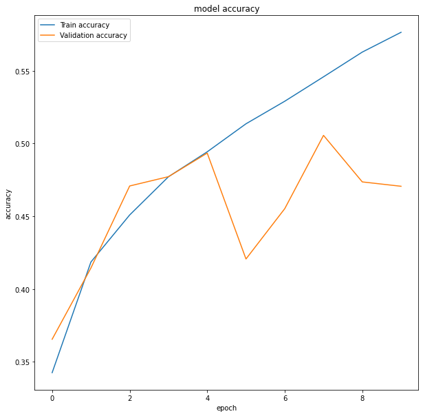

```python
loss_plt = plt.figure(figsize = (10, 10))
plt.plot(trained_network.history['accuracy'])
plt.plot(trained_network.history["val_accuracy"])
plt.title('model accuracy')
plt.ylabel('accuracy')
plt.xlabel('epoch')
plt.legend(["Train accuracy", "Validation accuracy"])
plt.show()
```

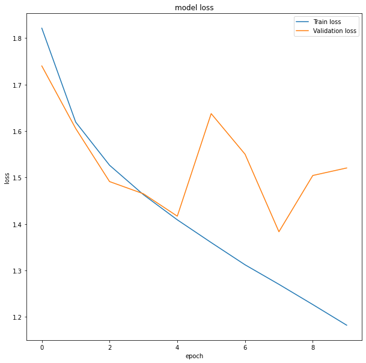

```python
loss_plt = plt.figure(figsize = (10, 10))
plt.plot(trained_network.history['loss'])
plt.plot(trained_network.history["val_loss"])
plt.title('model loss')
plt.ylabel('loss')
plt.xlabel('epoch')
plt.legend(["Train loss", "Validation loss"])
plt.show()
```

```python
labels = ['1', '2', '3', '4', '5', '6', '7', '8', '9', '10']
real_label = np.argmax(test_label, axis = 1)
predicted_label = np.argmax(network.predict(test_img), axis = 1)

#confusionmatrix, and also f1, precision calcuation
print('Test : ')
print(classification_report(real_label, predicted_label, digits=10))

real_label = np.argmax(train_label, axis = 1)
predicted_label = np.argmax(network.predict(train_img), axis = 1)

#confusionmatrix, and also f1, precision calcuation
print('Train : ')
print(classification_report(real_label, predicted_label, digits=10))
```

```
Test :
              precision    recall  f1-score   support

           0  0.5705128205 0.5340000000 0.5516528926      1000
           1  0.6893317702 0.5880000000 0.6346465192      1000
           2  0.5726872247 0.1300000000 0.2118989405      1000
           3  0.2728442728 0.4240000000 0.3320281911      1000
           4  0.4603174603 0.3480000000 0.3963553531      1000
           5  0.2992518703 0.6000000000 0.3993344426      1000
           6  0.7944444444 0.1430000000 0.2423728814      1000
           7  0.4152644231 0.6910000000 0.5187687688      1000
           8  0.7756410256 0.4840000000 0.5960591133      1000
           9  0.5212323064 0.6260000000 0.5688323489      1000

    accuracy                      0.4568000000     10000
   macro avg  0.5371527618 0.4568000000 0.4451949451     10000
weighted avg  0.5371527618 0.4568000000 0.4451949451     10000

Train :
              precision    recall  f1-score   support

           0  0.6161912752 0.5876000000 0.6015561016      5000
           1  0.7798372514 0.6900000000 0.7321731749      5000
           2  0.6680637049 0.1594000000 0.2573873728      5000
           3  0.3131181676 0.4812000000 0.3793755913      5000
           4  0.5188220230 0.4052000000 0.4550252667      5000
           5  0.3449531738 0.6630000000 0.4537987680      5000
           6  0.8557894737 0.1626000000 0.2732773109      5000
           7  0.4729942954 0.7794000000 0.5887151598      5000
           8  0.8341788205 0.5262000000 0.6453274467      5000
           9  0.6076074428 0.7380000000 0.6664860471      5000

    accuracy                      0.5192600000     50000
   macro avg  0.6011555628 0.5192600000 0.5053122240     50000
weighted avg  0.6011555628 0.5192600000 0.5053122240     50000
```

```python
network = models.Sequential()
network.add(layers.Input(3072))
network.add(layers.Flatten())
network.add(layers.Dense(4096, activation = 'relu'))
network.add(layers.Dense(2048, activation= 'relu'))
network.add(layers.Dense(1024, activation= 'relu'))
network.add(layers.Dense(512, activation= 'relu'))
network.add(layers.Dense(256, activation= 'relu'))
network.add(layers.Dense(128, activation= 'relu'))
network.add(layers.Dense(10, activation = 'softmax'))
network.compile(loss = 'categorical_crossentropy', optimizer = optimizers.SGD(learning_rate = 0.01, momentum = 0.9), metrics= ['accuracy'])
```

```python
trained_network = network.fit(train_img, train_label, batch_size = 32, epochs = 10, validation_split = 0.1, verbose = 1)
```

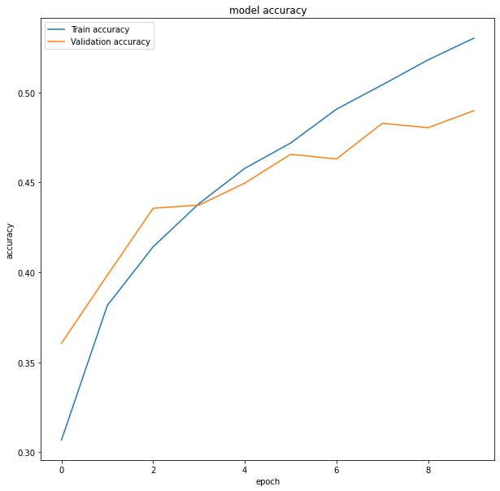

```python
loss_plt = plt.figure(figsize = (10, 10))
plt.plot(trained_network.history['accuracy'])
plt.plot(trained_network.history["val_accuracy"])
plt.title('model accuracy')
plt.ylabel('accuracy')
plt.xlabel('epoch')
plt.legend(["Train accuracy", "Validation accuracy"])
plt.show()
```

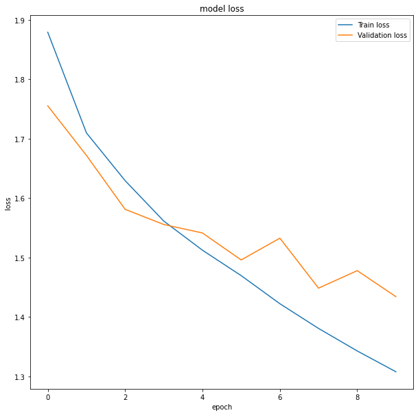

```python
loss_plt = plt.figure(figsize = (10, 10))
plt.plot(trained_network.history['loss'])
plt.plot(trained_network.history["val_loss"])
plt.title('model loss')
plt.ylabel('loss')
plt.xlabel('epoch')
plt.legend(["Train loss", "Validation loss"])
plt.show()
```

```python
labels = ['1', '2', '3', '4', '5', '6', '7', '8', '9', '10']
real_label = np.argmax(test_label, axis = 1)
predicted_label = np.argmax(network.predict(test_img), axis = 1)

#confusionmatrix, and also f1, precision calcuation
print('Test : ')
print(classification_report(real_label, predicted_label, digits=10))

real_label = np.argmax(train_label, axis = 1)
predicted_label = np.argmax(network.predict(train_img), axis = 1)

#confusionmatrix, and also f1, precision calcuation
print('Train : ')
print(classification_report(real_label, predicted_label, digits=10))
```

```
Test :
              precision    recall  f1-score   support

           0  0.4445901639 0.6780000000 0.5370297030      1000
           1  0.5617088608 0.7100000000 0.6272084806      1000
           2  0.3255190891 0.4860000000 0.3898916968      1000
           3  0.3866057839 0.2540000000 0.3065781533      1000
           4  0.5084337349 0.2110000000 0.2982332155      1000
           5  0.4708860759 0.3720000000 0.4156424581      1000
           6  0.5294676806 0.5570000000 0.5428849903      1000
           7  0.5776135164 0.5470000000 0.5618900873      1000
           8  0.6751824818 0.5550000000 0.6092206367      1000
           9  0.5574879227 0.5770000000 0.5670761671      1000

    accuracy                      0.4947000000     10000
   macro avg  0.5037495310 0.4947000000 0.4855655589     10000
weighted avg  0.5037495310 0.4947000000 0.4855655589     10000

Train :
              precision    recall  f1-score   support

           0  0.4645305907 0.7046000000 0.5599173554      5000
           1  0.5783151326 0.7414000000 0.6497808940      5000
           2  0.3695054945 0.5380000000 0.4381107492      5000
           3  0.4826527479 0.3144000000 0.3807678334      5000
           4  0.6270373921 0.2616000000 0.3691786622      5000
           5  0.5265772479 0.4240000000 0.4697540439      5000
           6  0.5881886643 0.5936000000 0.5908819431      5000
           7  0.6294094332 0.6352000000 0.6322914593      5000
           8  0.7383935151 0.6012000000 0.6627714695      5000
           9  0.6083943011 0.6320000000 0.6199725329      5000

    accuracy                      0.5446000000     50000
   macro avg  0.5613004520 0.5446000000 0.5373426943     50000
weighted avg  0.5613004520 0.5446000000 0.5373426943     50000
```

```python
network = models.Sequential()
network.add(layers.Input(3072))
network.add(layers.Flatten())
network.add(layers.Dense(4096, activation = 'relu'))
network.add(layers.Dense(2048, activation= 'relu'))
network.add(layers.Dense(1024, activation= 'relu'))
network.add(layers.Dense(512, activation= 'relu'))
network.add(layers.Dense(256, activation= 'relu'))
network.add(layers.Dense(128, activation= 'relu'))
network.add(layers.Dense(10, activation = 'softmax'))
network.compile(loss = 'categorical_crossentropy', optimizer = optimizers.SGD(learning_rate = 0.01, momentum = 0.98), metrics= ['accuracy'])
```

```python
trained_network = network.fit(train_img, train_label, batch_size = 32, epochs = 10, validation_split = 0.1, verbose = 1)
```

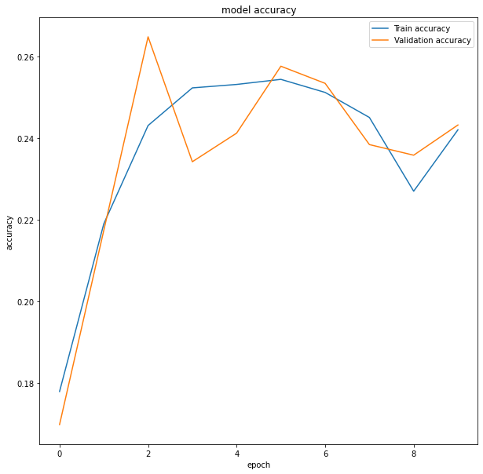

```python
loss_plt = plt.figure(figsize = (10, 10))
plt.plot(trained_network.history['accuracy'])
plt.plot(trained_network.history["val_accuracy"])
plt.title('model accuracy')
plt.ylabel('accuracy')
plt.xlabel('epoch')
plt.legend(["Train accuracy", "Validation accuracy"])
plt.show()
```

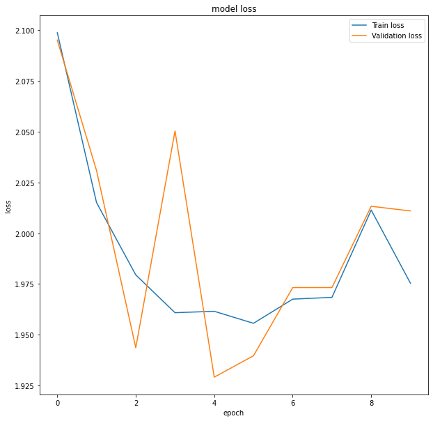

```python
loss_plt = plt.figure(figsize = (10, 10))
plt.plot(trained_network.history['loss'])
plt.plot(trained_network.history["val_loss"])
plt.title('model loss')
plt.ylabel('loss')
plt.xlabel('epoch')
plt.legend(["Train loss", "Validation loss"])
plt.show()
```

```python
labels = ['1', '2', '3', '4', '5', '6', '7', '8', '9', '10']
real_label = np.argmax(test_label, axis = 1)
predicted_label = np.argmax(network.predict(test_img), axis = 1)

#confusionmatrix, and also f1, precision calcuation
print('Test : ')
print(classification_report(real_label, predicted_label, digits=10))

real_label = np.argmax(train_label, axis = 1)
predicted_label = np.argmax(network.predict(train_img), axis = 1)

#confusionmatrix, and also f1, precision calcuation
print('Train : ')
print(classification_report(real_label, predicted_label, digits=10))
```

```
Test :
              precision    recall  f1-score   support

           0  0.3854545455 0.1060000000 0.1662745098      1000
           1  0.0000000000 0.0000000000 0.0000000000      1000
           2  0.0000000000 0.0000000000 0.0000000000      1000
           3  0.1666666667 0.0040000000 0.0078125000      1000
           4  0.1799949862 0.7180000000 0.2878332331      1000
           5  0.3486005089 0.2740000000 0.3068309071      1000
           6  0.2530864198 0.1230000000 0.1655450875      1000
           7  0.0000000000 0.0000000000 0.0000000000      1000
           8  0.2963197970 0.4670000000 0.3625776398      1000
           9  0.2502632503 0.7130000000 0.3704858405      1000

    accuracy                      0.2405000000     10000
   macro avg  0.1880386174 0.2405000000 0.1667359718     10000
weighted avg  0.1880386174 0.2405000000 0.1667359718     10000
```

```
Train :
              precision    recall  f1-score   support

           0  0.3995117982 0.0982000000 0.1576497030      5000
           1  0.0925925926 0.0010000000 0.0019786308      5000
           2  0.0000000000 0.0000000000 0.0000000000      5000
           3  0.2413793103 0.0098000000 0.0188352873      5000
           4  0.1816557779 0.7118000000 0.2894437215      5000
           5  0.3493358192 0.2998000000 0.3226778603      5000
           6  0.2863809928 0.1350000000 0.1834987087      5000
           7  0.0000000000 0.0000000000 0.0000000000      5000
           8  0.3162349968 0.5006000000 0.3876113047      5000
           9  0.2596977505 0.7458000000 0.3852471719      5000

    accuracy                      0.2502000000     50000
   macro avg  0.2126789038 0.2502000000 0.1746942388     50000
weighted avg  0.2126789038 0.2502000000 0.1746942388     50000
```

طبق نتایج بالا بهترین نتیجه (Test Accuracy) متعلق به مدلی است که در آن مقدار momentum را برابر با 0.9 قرار دادیم. همچنین میبینیم وقتی که مقدار momentum را برابر با 0.98 قرار می دهیم، دقت مدل به شدت پایین می آید و کارکرد خوبی ندارد. همواره با افزایش مقدار momentum نتیجه بهبود پیدا نمی کند. در واقع وقتی مقدار momentum خیلی کوچک باشد کمکی به مدل ما نمی کند و وقتی مقدار آن خیلی زیاد باشد باعث می شود مدل ما رفتار رندوم داشته باشد و به مقدار بهینه میل نکند و کارکرد خوبی نداشته باشد.

```python
network = models.Sequential()
network.add(layers.Input(3072))
network.add(layers.Flatten())
network.add(layers.Dense(4096, activation = 'relu'))
network.add(layers.Dense(2048, activation= 'relu'))
network.add(layers.Dense(1024, activation= 'relu'))
network.add(layers.Dense(512, activation= 'relu'))
network.add(layers.Dense(256, activation= 'relu'))
network.add(layers.Dense(128, activation= 'relu'))
network.add(layers.Dense(10, activation = 'softmax'))
network.compile(loss = 'categorical_crossentropy', optimizer = 'adam', metrics= ['accuracy'])
```

```python
trained_network = network.fit(train_img, train_label, batch_size = 32, epochs = 10, validation_split = 0.1, verbose = 1)
```

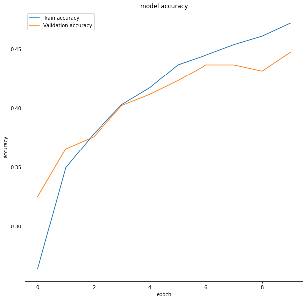

```python
loss_plt = plt.figure(figsize = (10, 10))
plt.plot(trained_network.history['accuracy'])
plt.plot(trained_network.history["val_accuracy"])
plt.title('model accuracy')
plt.ylabel('accuracy')
plt.xlabel('epoch')
plt.legend(["Train accuracy", "Validation accuracy"])
plt.show()
```

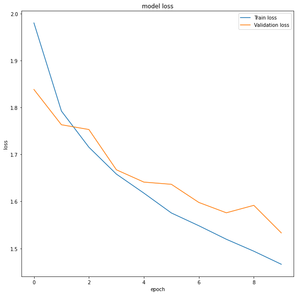

```python
loss_plt = plt.figure(figsize = (10, 10))
plt.plot(trained_network.history['loss'])
plt.plot(trained_network.history["val_loss"])
plt.title('model loss')
plt.ylabel('loss')
plt.xlabel('epoch')
plt.legend(["Train loss", "Validation loss"])
plt.show()
```

```python
labels = ['1', '2', '3', '4', '5', '6', '7', '8', '9', '10']
real_label = np.argmax(test_label, axis = 1)
predicted_label = np.argmax(network.predict(test_img), axis = 1)

#confusionmatrix, and also f1, precision calcuation
print('Test : ')
print(classification_report(real_label, predicted_label, digits=10))

real_label = np.argmax(train_label, axis = 1)
predicted_label = np.argmax(network.predict(train_img), axis = 1)

#confusionmatrix, and also f1, precision calcuation
print('Train : ')
print(classification_report(real_label, predicted_label, digits=10))
```

```
Test :
              precision    recall  f1-score   support

           0  0.4500693481 0.6490000000 0.5315315315      1000
           1  0.5965665236 0.5560000000 0.5755693582      1000
           2  0.3127833182 0.3450000000 0.3281027104      1000
           3  0.3065159574 0.4610000000 0.3682108626      1000
           4  0.4170918367 0.3270000000 0.3665919283      1000
           5  0.4501061571 0.2120000000 0.2882392930      1000
           6  0.5149023638 0.5010000000 0.5078560568      1000
           7  0.5341880342 0.5000000000 0.5165289256      1000
           8  0.5272255834 0.6100000000 0.5656003709      1000
           9  0.6131805158 0.4280000000 0.5041224971      1000

    accuracy                      0.4589000000     10000
   macro avg  0.4722629638 0.4589000000 0.4552353534     10000
weighted avg  0.4722629638 0.4589000000 0.4552353534     10000

Train :
              precision    recall  f1-score   support

           0  0.4595500908 0.6578000000 0.5410874393      5000
           1  0.6200042292 0.5864000000 0.6027340939      5000
           2  0.3563063928 0.3712000000 0.3636007444      5000
           3  0.3211688483 0.4858000000 0.3866910770      5000
           4  0.4321872015 0.3620000000 0.3939921637      5000
           5  0.5004413063 0.2268000000 0.3121387283      5000
           6  0.5240218934 0.5170000000 0.5204872647      5000
           7  0.5716395864 0.5418000000 0.5563199507      5000
           8  0.5689841499 0.6318000000 0.5987490523      5000
           9  0.6219978166 0.4558000000 0.5260849492      5000

    accuracy                      0.4836400000     50000
   macro avg  0.4976301515 0.4836400000 0.4801885464     50000
weighted avg  0.4976301515 0.4836400000 0.4801885464     50000
```

الگوریتم Adam یک الگوریتم بهینه سازی است که می توان از آن به جای روش گرادیان کاهشی تصادفی کلاسیک برای به روزرسانی وزن های شبکه بر اساس تکرار در داده های آموزشی استفاده کرد. مزیت ها : به آسانی پیاده سازی می شود - به لحاظ محاسباتی بهینه است - به حافظه کمی نیاز دارد - برای مسائلی بسیار مناسب است که به لحاظ داده یا پارامتر بزرگ محسوب می شوند - الگوریتم خوبی برای مسائلی است که دارای گرادیان های بسیار نویزدارد یا نامتراکم هستند. طبق نتایج با استفاده از این optimizer مقدار دقت تغییر آنچنانی ای نکرد اما مقداری محاسبات سریع تر انجام شد.

تاثیر Epoch :

خیر، در همه مسائل نیازی به تمرین در چندین epoch نیست. وقتی در بعضی از زمان ها دیتای کافی برای ترین نداریم از چند epoch استفاده می کنیم تا در هر epoch دیتای تکراری ترین شود و feature ها مشخص شوند. اما در مواقعی که به اندازه ی کافی دیتا داریم، یک epoch هم می تواند کافی باشد. خیر، همواره استفاده از تعداد epoch های بیشتر برای تمرین مفید نیست. وقتی ما تعداد epoch ها را خیلی زیاد قرار دهیم، ممکن است مدل ما Overfit شود زیرا به تعداد زیادی دیتا را تمرین می دهیم و مدل ما ممکن است حتی نویزها را هم تمرین دهد. بنابراین دقت روی دیتای دست نیز پایین می آید و مدل کارکرد خوبی ندارد. راه مقابله با آن Eearly Stopping می باشد. در واقع در این روش هر وقت که دقت برای Validation Set شروع به کاهش کرد، آموزش را متوقف می کنیم.

```python
network = models.Sequential()
network.add(layers.Input(3072))
network.add(layers.Flatten())
network.add(layers.Dense(4096, activation = 'relu'))
network.add(layers.Dense(2048, activation= 'relu'))
network.add(layers.Dense(1024, activation= 'relu'))
network.add(layers.Dense(512, activation= 'relu'))
network.add(layers.Dense(256, activation= 'relu'))
network.add(layers.Dense(128, activation= 'relu'))
network.add(layers.Dense(10, activation = 'softmax'))
network.compile(loss = 'categorical_crossentropy', optimizer = 'adam', metrics= ['accuracy'])
```

Epoch = 20

```python
trained_network = network.fit(train_img, train_label, batch_size = 32, epochs = 20, validation_split = 0.1, verbose = 1)
```

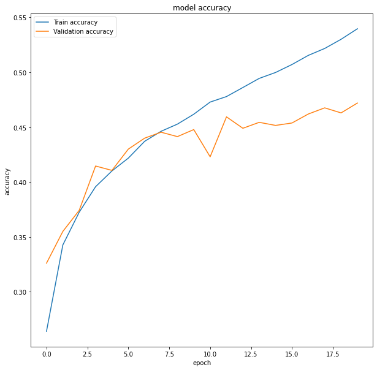

```python
loss_plt = plt.figure(figsize = (10, 10))
plt.plot(trained_network.history['accuracy'])
plt.plot(trained_network.history["val_accuracy"])
plt.title('model accuracy')
plt.ylabel('accuracy')
plt.xlabel('epoch')
plt.legend(["Train accuracy", "Validation accuracy"])
plt.show()
```

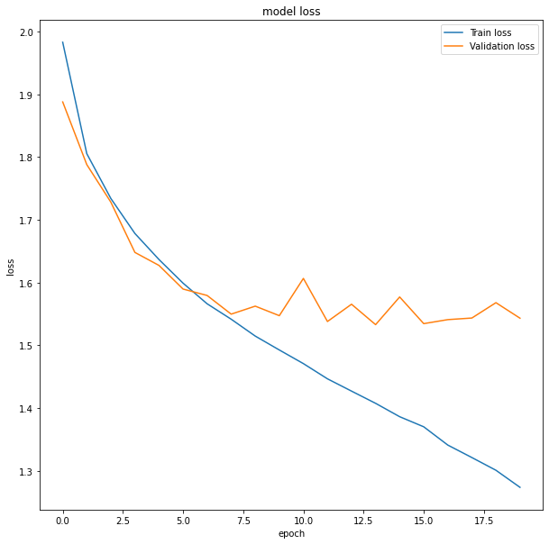

```python
loss_plt = plt.figure(figsize = (10, 10))
plt.plot(trained_network.history['loss'])
plt.plot(trained_network.history["val_loss"])
plt.title('model loss')
plt.ylabel('loss')
plt.xlabel('epoch')
plt.legend(["Train loss", "Validation loss"])
plt.show()
```

```python
labels = ['1', '2', '3', '4', '5', '6', '7', '8', '9', '10']
real_label = np.argmax(test_label, axis = 1)
predicted_label = np.argmax(network.predict(test_img), axis = 1)

#confusionmatrix, and also f1, precision calcuation
print('Test : ')
print(classification_report(real_label, predicted_label, digits=10))

real_label = np.argmax(train_label, axis = 1)
predicted_label = np.argmax(network.predict(train_img), axis = 1)

#confusionmatrix, and also f1, precision calcuation
print('Train : ')
print(classification_report(real_label, predicted_label, digits=10))
```

```
Test :
              precision    recall  f1-score   support

           0  0.5004191115 0.5970000000 0.5444596443      1000
           1  0.6270718232 0.4540000000 0.5266821346      1000
           2  0.4028892456 0.2510000000 0.3093037585      1000
           3  0.2959582790 0.2270000000 0.2569326542      1000
           4  0.4059139785 0.4530000000 0.4281663516      1000
           5  0.3724007561 0.3940000000 0.3828960155      1000
           6  0.5083507307 0.4870000000 0.4974463739      1000
           7  0.4926605505 0.5370000000 0.5138755981      1000
           8  0.5434412266 0.6380000000 0.5869365225      1000
           9  0.4726291442 0.6130000000 0.5337396604      1000

    accuracy                      0.4651000000     10000
   macro avg  0.4621734846 0.4651000000 0.4580438714     10000
weighted avg  0.4621734846 0.4651000000 0.4580438714     10000

Train :
              precision    recall  f1-score   support

           0  0.5524755927 0.6338000000 0.5903502235      5000
           1  0.7378740970 0.5720000000 0.6444344299      5000
           2  0.5319920844 0.3226000000 0.4016434263      5000
           3  0.4246348856 0.3082000000 0.3571676903      5000
           4  0.4755453906 0.5406000000 0.5059902658      5000
           5  0.4662588061 0.5030000000 0.4839330383      5000
           6  0.6087228715 0.5834000000 0.5957924837      5000
           7  0.5977926542 0.6608000000 0.6277191983      5000
           8  0.6206538661 0.7176000000 0.6656154346      5000
           9  0.5408459307 0.7084000000 0.6133864404      5000

    accuracy                      0.5550400000     50000
   macro avg  0.5556796179 0.5550400000 0.5486032631     50000
weighted avg  0.5556796179 0.5550400000 0.5486032631     50000
```

Epoch = 30

```python
network = models.Sequential()
network.add(layers.Input(3072))
network.add(layers.Flatten())
network.add(layers.Dense(4096, activation = 'relu'))
network.add(layers.Dense(2048, activation= 'relu'))
network.add(layers.Dense(1024, activation= 'relu'))
network.add(layers.Dense(512, activation= 'relu'))
network.add(layers.Dense(256, activation= 'relu'))
network.add(layers.Dense(128, activation= 'relu'))
network.add(layers.Dense(10, activation = 'softmax'))
network.compile(loss = 'categorical_crossentropy', optimizer = 'adam', metrics= ['accuracy'])
```

```python
trained_network = network.fit(train_img, train_label, batch_size = 32, epochs = 30, validation_split = 0.1, verbose = 1)
```

[output not shown]

تاثیر Loss Function :

[figure not shown]

```python
network = models.Sequential()
network.add(layers.Input(3072))
network.add(layers.Flatten())
network.add(layers.Dense(4096, activation = 'relu'))
network.add(layers.Dense(2048, activation= 'relu'))
network.add(layers.Dense(1024, activation= 'relu'))
network.add(layers.Dense(512, activation= 'relu'))
network.add(layers.Dense(256, activation= 'relu'))
network.add(layers.Dense(128, activation= 'relu'))
network.add(layers.Dense(10, activation = 'softmax'))
network.compile(loss = 'mean_squared_error', optimizer = 'adam', metrics= ['accuracy'])
```

```python
trained_network = network.fit(train_img, train_label, batch_size = 32, epochs = 10, validation_split = 0.1, verbose = 1)
```

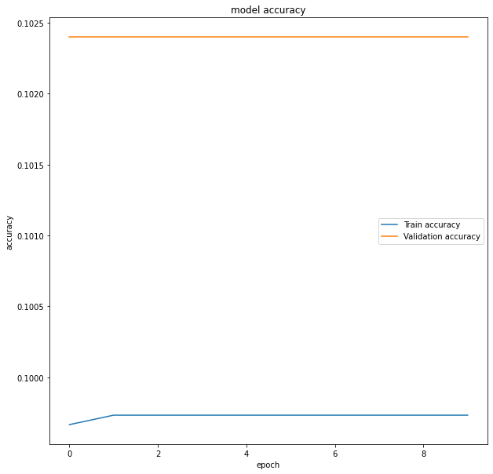

```python
loss_plt = plt.figure(figsize = (10, 10))
plt.plot(trained_network.history['accuracy'])
plt.plot(trained_network.history["val_accuracy"])
plt.title('model accuracy')
plt.ylabel('accuracy')
plt.xlabel('epoch')
plt.legend(["Train accuracy", "Validation accuracy"])
plt.show()
```

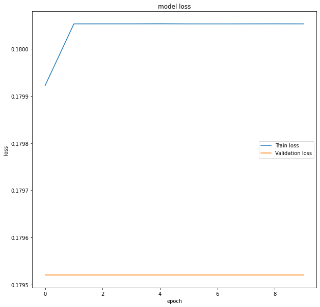

```python
loss_plt = plt.figure(figsize = (10, 10))
plt.plot(trained_network.history['loss'])
plt.plot(trained_network.history["val_loss"])
plt.title('model loss')
plt.ylabel('loss')
plt.xlabel('epoch')
plt.legend(["Train loss", "Validation loss"])
plt.show()
```

طبق نتایج بالا دقت به شدت پایین می آید و اصلا مدل خوبی نیست. دلیل آن هم این است که MSE برای مسائل Regression و Croos Entropy برای مسائل Classification استفاده می شود. در واقع در مسائل Classification تعداد جواب های ممکن محدود است و MSE به درستی جواب نمی دهد.

تاثیر Regularization

لایه هایی به اسم Dropout به شبکه عصبی اضافه می کنیم.

```python
network = models.Sequential()
network.add(layers.Input(3072))
network.add(layers.Flatten())
network.add(layers.Dense(4096, activation = 'relu'))
network.add(layers.Dropout(0.1))
network.add(layers.Dense(2048, activation = 'relu'))
network.add(layers.Dropout(0.1))
network.add(layers.Dense(1024, activation = 'relu'))
network.add(layers.Dropout(0.1))
network.add(layers.Dense(512, activation = 'relu'))
network.add(layers.Dropout(0.1))
network.add(layers.Dense(256, activation = 'relu'))
network.add(layers.Dropout(0.1))
network.add(layers.Dense(128, activation = 'relu'))
network.add(layers.Dropout(0.1))
network.add(layers.Dense(10, activation = 'softmax'))
network.compile(loss = 'categorical_crossentropy', optimizer = 'adam', metrics= ['accuracy'])
```

```python
network.summary()
```

```
Model: "sequential_9"
_________________________________________________________________
 Layer (type)                Output Shape              Param #
=================================================================
 flatten_9 (Flatten)         (None, 3072)              0

 dense_59 (Dense)            (None, 4096)              12587008

 dropout_6 (Dropout)         (None, 4096)              0

 dense_60 (Dense)            (None, 2048)              8390656

 dropout_7 (Dropout)         (None, 2048)              0

 dense_61 (Dense)            (None, 1024)              2098176

 dropout_8 (Dropout)         (None, 1024)              0

 dense_62 (Dense)            (None, 512)               524800

 dropout_9 (Dropout)         (None, 512)               0

 dense_63 (Dense)            (None, 256)               131328

 dropout_10 (Dropout)        (None, 256)               0

 dense_64 (Dense)            (None, 128)               32896

 dropout_11 (Dropout)        (None, 128)               0

 dense_65 (Dense)            (None, 10)                1290

=================================================================
Total params: 23,766,154
Trainable params: 23,766,154
Non-trainable params: 0
_________________________________________________________________
```

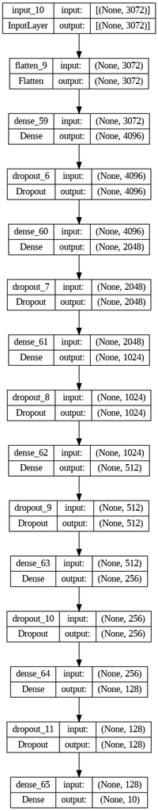

```python
plot_model(network, show_shapes=True, expand_nested=True)
```

```python
trained_network = network.fit(train_img, train_label, batch_size = 32, epochs = 10, validation_split = 0.1, verbose = 1)
```

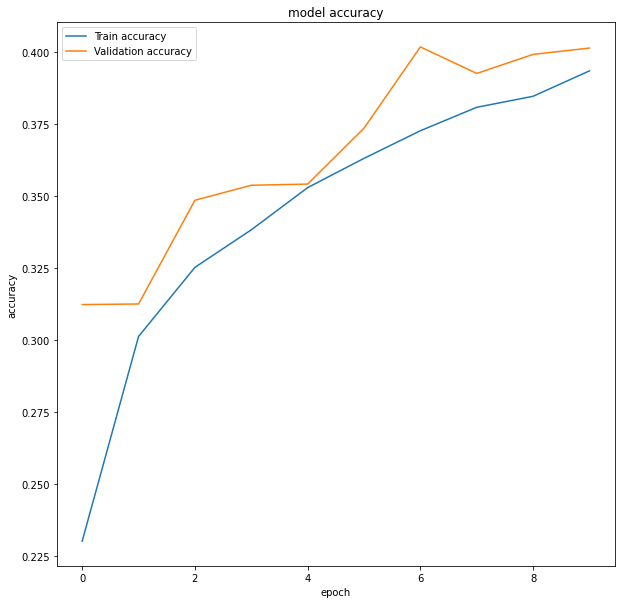

```python
loss_plt = plt.figure(figsize = (10, 10))
plt.plot(trained_network.history['accuracy'])
plt.plot(trained_network.history["val_accuracy"])
plt.title('model accuracy')
plt.ylabel('accuracy')
plt.xlabel('epoch')
plt.legend(["Train accuracy", "Validation accuracy"])
plt.show()
```

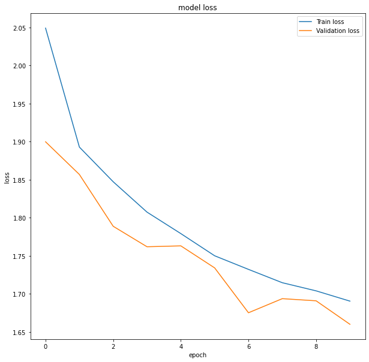

```python
loss_plt = plt.figure(figsize = (10, 10))
plt.plot(trained_network.history['loss'])
plt.plot(trained_network.history["val_loss"])
plt.title('model loss')
plt.ylabel('loss')
plt.xlabel('epoch')
plt.legend(["Train loss", "Validation loss"])
plt.show()
```

```python
test_loss, test_acc = network.evaluate(test_img, test_label, verbose = 0)
print("loss in test data is: ", test_loss)
print("accuracy in test data is : ", test_acc)
```

```
loss in test data is:  1.6398259401321411
accuracy in test data is :  0.4092999994754791
```

```python
labels = ['1', '2', '3', '4', '5', '6', '7', '8', '9', '10']
real_label = np.argmax(test_label, axis = 1)
predicted_label = np.argmax(network.predict(test_img), axis = 1)

#confusionmatrix, and also f1, precision calcuation
print('Test : ')
print(classification_report(real_label, predicted_label, digits=10))

real_label = np.argmax(train_label, axis = 1)
predicted_label = np.argmax(network.predict(train_img), axis = 1)

#confusionmatrix, and also f1, precision calcuation
print('Train : ')
print(classification_report(real_label, predicted_label, digits=10))
```

```
Test :
              precision    recall  f1-score   support

           0  0.4097978227 0.5270000000 0.4610673666      1000
           1  0.4138613861 0.6270000000 0.4986083499      1000
           2  0.2471910112 0.0880000000 0.1297935103      1000
           3  0.3216689098 0.2390000000 0.2742398164      1000
           4  0.3141624730 0.4370000000 0.3655374320      1000
           5  0.4860759494 0.1920000000 0.2752688172      1000
           6  0.4500494560 0.4550000000 0.4525111885      1000
           7  0.3994800693 0.4610000000 0.4280408542      1000
           8  0.5412573674 0.5510000000 0.5460852329      1000
           9  0.4562334218 0.5160000000 0.4842796809      1000

    accuracy                      0.4093000000     10000
   macro avg  0.4039777867 0.4093000000 0.3915432249     10000
weighted avg  0.4039777867 0.4093000000 0.3915432249     10000

Train :
              precision    recall  f1-score   support

           0  0.4100209441 0.5090000000 0.4541804229      5000
           1  0.4088883229 0.6422000000 0.4996498872      5000
           2  0.2659768716 0.0874000000 0.1315670631      5000
           3  0.3320724129 0.2458000000 0.2824962648      5000
           4  0.3138461538 0.4488000000 0.3693827160      5000
           5  0.5057859209 0.2098000000 0.2965790218      5000
           6  0.4633895516 0.4506000000 0.4569052930      5000
           7  0.4269488900 0.4962000000 0.4589769679      5000
           8  0.5576961271 0.5616000000 0.5596412556      5000
           9  0.4676906780 0.5298000000 0.4968117029      5000

    accuracy                      0.4181200000     50000
   macro avg  0.4152315873 0.4181200000 0.4006190595     50000
weighted avg  0.4152315873 0.4181200000 0.4006190595     50000
```

در یادگیری ماشین، یکی از راه های جلوگیری از overfitting، رگولاریزاسیون است. رگولاریزاسیون با اضافه کردن یک پنالتی به تابع هزینه، overfitting را کاهش می دهد. با اضافه کردن این پنالتی، مدل به گونه ای آموزش داده می شود که وزن های ویژگی های وابسته، آپدیت نمی شوند. Dropout یک رویکرد برای رگولاریزاسیون در شبکه های عصبی است که باعث کاهش یادگیری های تکراری میان نورون ها می شود. Dropout یعنی اینکه در هر مرحله از آموزش، نودهایی از شبکه، با احتمال 1-p کنار گذاشته شده و نودهای دیگری با احتمال p، حفظ می شوند. بنابراین یک شبکه کاهش یافته باقی می ماند.همچنین لایه های Dropout در مرحله آموزش حضور دارند اما در مرحله پیش بینی نقشی ندارند. طبق نتایج بالا می توانیم ببینیم که دقت افزایش پیدا نکرده است اما مدل ما از نظر Overfitting بهبود یافته است.

[figure not shown]